# Gapminder Exploration

Mike Marin

# 1 The Gapminder Data

## 1.1 Variables Collected

Here, we can see the **variables** collected in the data set:

```
## [1] "country"   "continent" "year"      "lifeExp"   "pop"       "gdpPercap"
```

## 1.2 Some Basic Summaries

The data dimensions are as folows:

```r
dim(gapminder)
```

```
## [1] 1704    6
```

## 1.3 The Full Data

To explore the full data, you can play around here:

```r
# the datatable makes it easier to do something in HTML
datatable(as_tibble(gapminder))
```

|  | country | continent | year | lifeExp | pop | gdpPercap |
| --- | --- | --- | --- | --- | --- | --- |
| 1 | Afghanistan | Asia | 1952 | 28.801 | 8425333 | 779.4453145 |
| 2 | Afghanistan | Asia | 1957 | 30.332 | 9240934 | 820.8530296 |
| 3 | Afghanistan | Asia | 1962 | 31.997 | 10267083 | 853.10071 |
| 4 | Afghanistan | Asia | 1967 | 34.02 | 11537966 | 836.1971382 |
| 5 | Afghanistan | Asia | 1972 | 36.088 | 13079460 | 739.9811058 |
| 6 | Afghanistan | Asia | 1977 | 38.438 | 14880372 | 786.11336 |
| 7 | Afghanistan | Asia | 1982 | 39.854 | 12881816 | 978.0114388 |
| 8 | Afghanistan | Asia | 1987 | 40.822 | 13867957 | 852.3959448 |
| 9 | Afghanistan | Asia | 1992 | 41.674 | 16317921 | 649.3413952 |
| 10 | Afghanistan | Asia | 1997 | 41.763 | 22227415 | 635.341351 |

[output cut: 1694 more lines]

# 2 Some Univariate Summaries

It is of interest to take a look at each of the variables, and provide a quick summary, both numerically as well as graphically

## 2.1 A Quick Glance

Following are basic univariate summaries for each of the variables:

```
##         country        continent        year         lifeExp
##  Afghanistan:  12   Africa  :624   Min.   :1952   Min.   :23.60
##  Albania    :  12   Americas:300   1st Qu.:1966   1st Qu.:48.20
##  Algeria    :  12   Asia    :396   Median :1980   Median :60.71
##  Angola     :  12   Europe  :360   Mean   :1980   Mean   :59.47
##  Argentina  :  12   Oceania : 24   3rd Qu.:1993   3rd Qu.:70.85
##  Australia  :  12                  Max.   :2007   Max.   :82.60
##  (Other)    :1632
##       pop              gdpPercap
##  Min.   :6.001e+04   Min.   :   241.2
##  1st Qu.:2.794e+06   1st Qu.:  1202.1
##  Median :7.024e+06   Median :  3531.8
##  Mean   :2.960e+07   Mean   :  7215.3
##  3rd Qu.:1.959e+07   3rd Qu.:  9325.5
##  Max.   :1.319e+09   Max.   :113523.1
##
```

## 2.2 Countires and Continents

Which countries are represented in the data?

- In total there are 142 countries represented. They are not all listed here for the sake of space.
- There are a total of 5 geopolitical continents recorded:
  - Africa
  - Asia
  - Europe
  - Americas (made up of North America and South America are combined)
  - Oceania (Australia, New Zealand, and surrounding island countries)
  - Antarctica is not included in the data

## 2.3 Years Recorded

The data was collected for a number of years. The years the data was collected for were:

```
##  [1] "1952" "1957" "1962" "1967" "1972" "1977" "1982" "1987" "1992" "1997"
## [11] "2002" "2007"
```

## 2.4 Life Expectancy, GDPperCap, and Population

These are all numeric variables, and all likely related to one another. Following are basic summaries and plots for each:

### 2.4.1 Life Expectancy

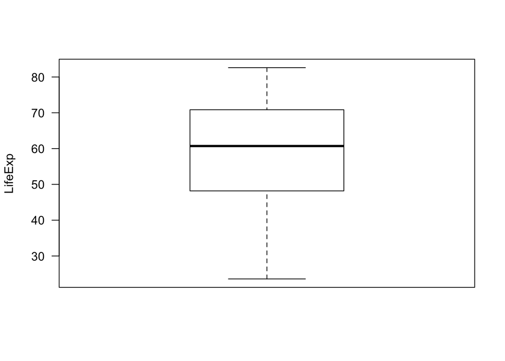

```r
boxplot(gapminder$lifeExp, ylab="LifeExp", las=1)
```

```r
summary(gapminder$lifeExp)
```

```
##    Min. 1st Qu.  Median    Mean 3rd Qu.    Max.
##   23.60   48.20   60.71   59.47   70.85   82.60
```

Wow, 23 years life expectancy?! Where did that come from?

```
## # A tibble: 1 x 6
##   country continent  year lifeExp     pop gdpPercap
##   <fct>   <fct>     <int>   <dbl>   <int>     <dbl>
## 1 Rwanda  Africa     1992    23.6 7290203      737.
```

Oh, ok, we all know that there was a **LOT** going on there at that time!

### 2.4.2 GDP Per Capita

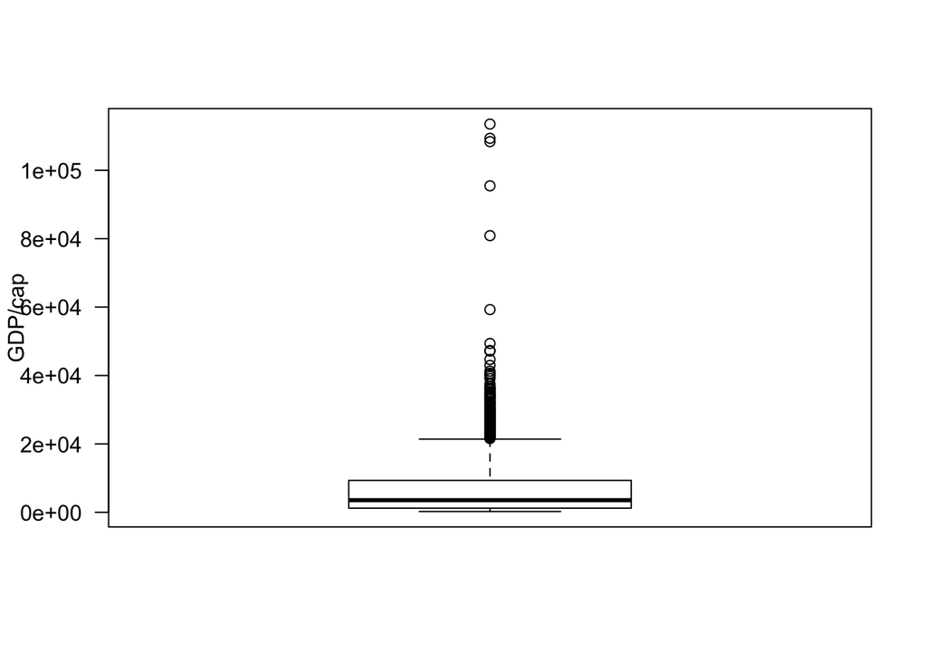

```r
boxplot(gapminder$gdpPercap, ylab="GDP/cap", las=1)
```

```r
summary(gapminder$gdpPercap)
```

```
##     Min.  1st Qu.   Median     Mean  3rd Qu.     Max.
##    241.2   1202.1   3531.8   7215.3   9325.5 113523.1
```

And a quick note that since GDP/cap is a rate, it may be better to be exploring it on the log(ln)-scale

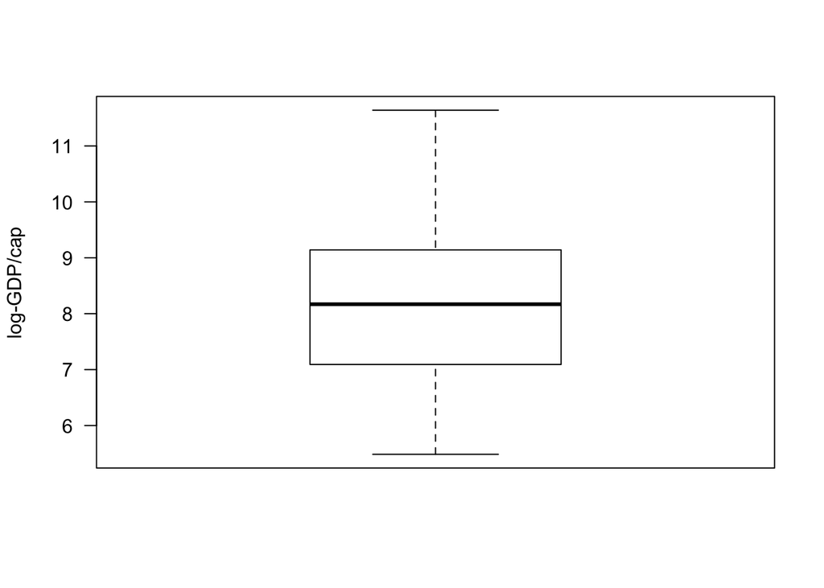

```r
boxplot(log(gapminder$gdpPercap), ylab="log-GDP/cap", las=1)
```

```r
summary(log(gapminder$gdpPercap))
```

```
##    Min. 1st Qu.  Median    Mean 3rd Qu.    Max.
##   5.485   7.092   8.170   8.159   9.141  11.640
```

### 2.4.3 Population

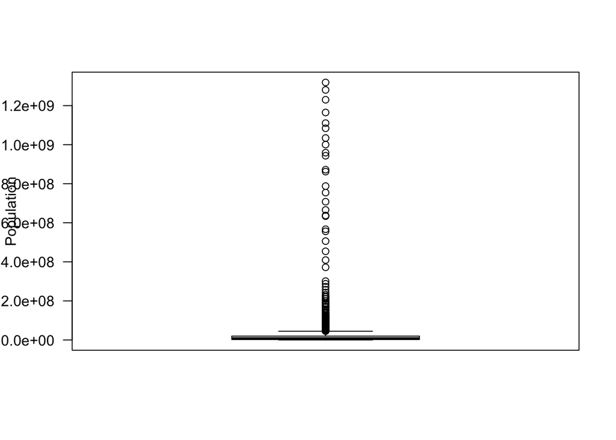

```r
boxplot(gapminder$pop, ylab="Population", las=1)
```

```r
summary(gapminder$pop)
```

```
##      Min.   1st Qu.    Median      Mean   3rd Qu.      Max.
## 6.001e+04 2.794e+06 7.024e+06 2.960e+07 1.959e+07 1.319e+09
```

Again, it may be better to examine this on the log-scale, as populations tend to grow exponentially

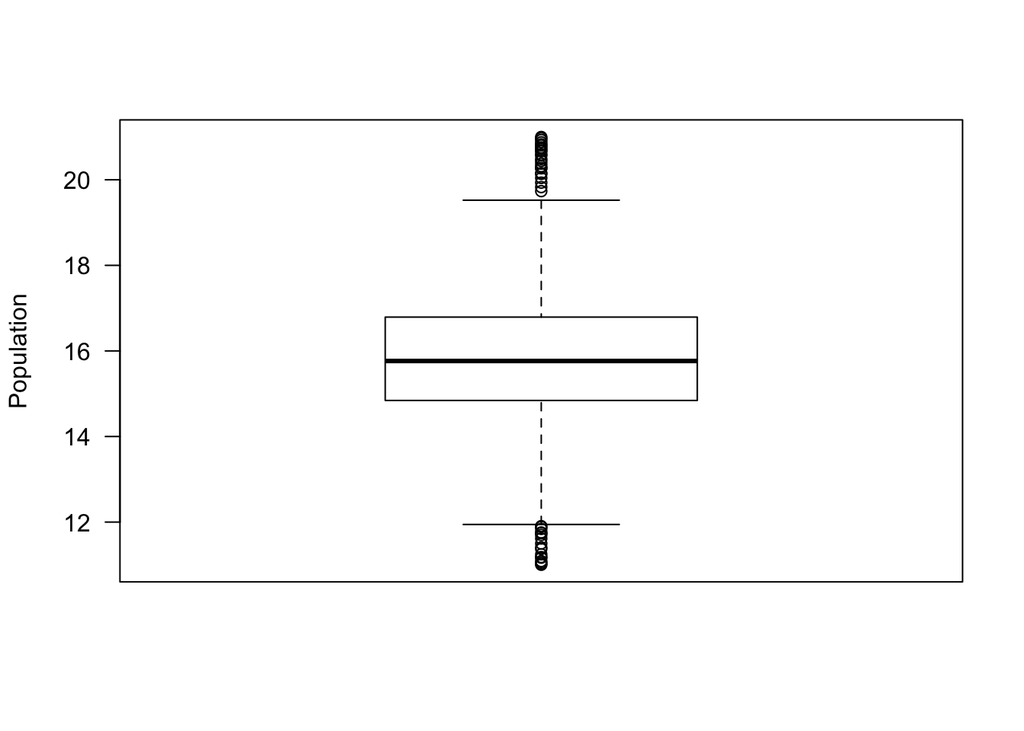

```r
boxplot(log(gapminder$pop), ylab="Population", las=1)
```

```r
summary(log(gapminder$pop))
```

```
##    Min. 1st Qu.  Median    Mean 3rd Qu.    Max.
##   11.00   14.84   15.76   15.77   16.79   21.00
```

# 3 Some Bivariate Summaries

We may be interested in examining relationships between some of the variables. Following are a few of interest.

Note, we are ignoring the fact that the same countires have measurements taken for multiple years, for the time being…

## 3.1 Life Expectancy and GDP

It is reasonable to hypothesize that these would be related. Following is a visual examination of their relationship

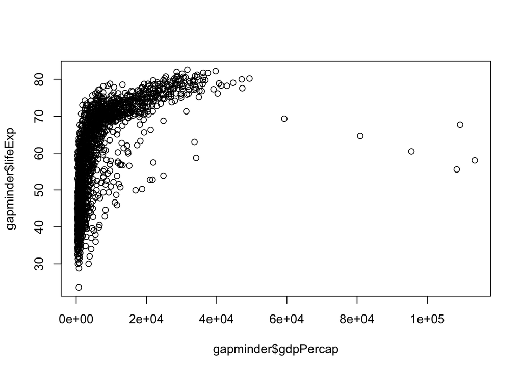

Pearson’s correlation:

```r
cor(gapminder$gdpPercap, gapminder$lifeExp)
```

```
## [1] 0.5837062
```

It’s not surprising to see they are associated. It also isn’t surprising to see that it is a non-liear relationship.

First, let’s calculate Spearman’s correlation to address the non-linearity, as it does appear a monotonic association:

```r
cor(gapminder$gdpPercap, gapminder$lifeExp, method="spearman")
```

```
## [1] 0.8264712
```

yup, it looks much more reasonable

Let’s look at the same plot, but this time using the log-GDP-per-capita, as it makes sense to examine it on this scale

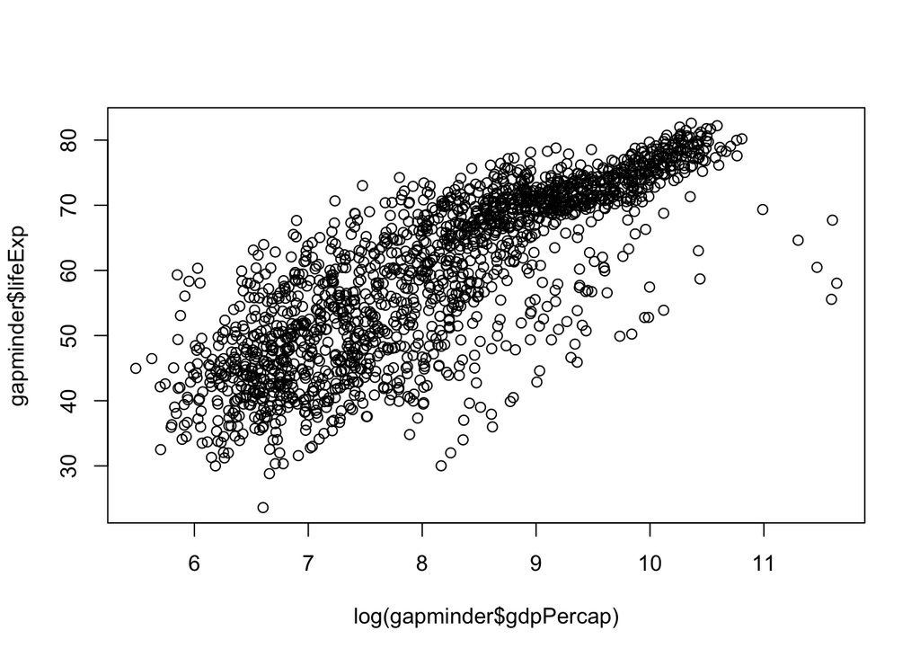

That looks like it would be easier to model. Let’s also take a quick look at Pearson’s correlation when we use log-GDP…

```r
cor(log(gapminder$gdpPercap), gapminder$lifeExp, method="pearson")
```

```
## [1] 0.8076179
```

Let’s not get carried away…we will stop here

## 3.2 Continent and GDP

It is also reasonable to explore if GDP per captia varies by continent (again, ignoring the fact that we have measurements for multiple years)

Let’s look at a plot of this

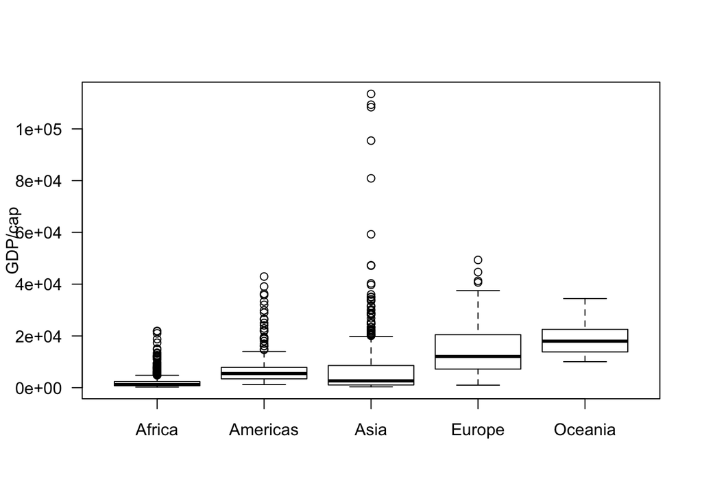

We can see an associaition. And as before, it may be more reasonable to examine GDP per capita on the *log-scale* as this variable is a **rate**

Let’s look at that here…

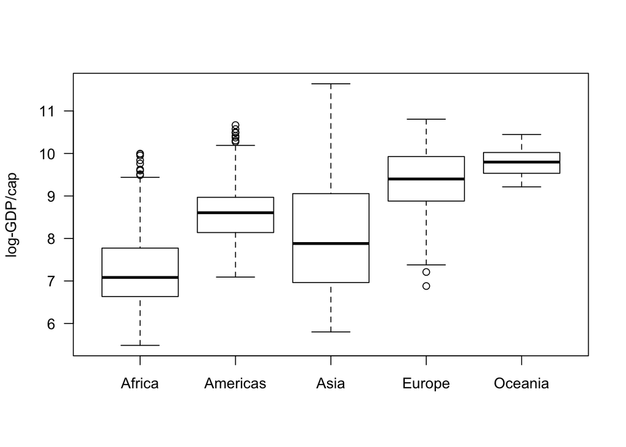

## 3.3 No More…

I wont get carried away, as the point of this exercise is working with R Markdown and Git(Hub), and not the actual data analysis…although, this is a **VERY** interesting dataset, and I will be exploring it further on my own, for myself :)